# Fourth Week: Hypothesis Testing

TIMSS Analysis

Ali Gorji

2018-03-09 02:24:41

# تمرین سری چهارم: چقدر ریاضی بلدیم و چرا؟

لطفا مقاله زیر را مطالعه بفرمایید.

[چرایی رتبه ضعیف ایران در آزمون تیمز](https://goo.gl/gX8DZc)

> با استفاده از داده های ارزیابی تیمز ۲۰۱۵ ادعاهای زیر را مورد ارزیابی قراردهید. برای هر سوال علاوه بر استدلال آماری که در غالب آزمون فرض تعریف می شود از تصویرسازی مناسب باهر دو ابزار ggplot2 و highcharter استفاده نمایید. به دلخواه به هفت گزاره از موارد زیر پاسخ دهید.

۱. میران رضایت معلمان در پیشرفت تحصیلی دانش آموزان موثر است.  
از آن جایی که میزان رضایت معلمان سوالی با جواب های سه گزینه ای است با ANOVA Test بررسی می کنیم که آیا نتایج وابسته از جواب این سوال است یا خبر  
با اینکه اختلاف کمی میان میانگین ها مشاهده می شود اما ANOVA test فرض عدم ارتباط بین میزان رضایت شغلی و موفقیت را رد می کند.

```r
library(readr)
library(dplyr)
```

```r
library(ggplot2)
library(highcharter)
library(labelled)
bcg = read_rds("~/Documents/Sharif/Term 6/Data Analysis/Homework/hw_04/files/data/bcg.rds") #school
bsa = read_rds("~/Documents/Sharif/Term 6/Data Analysis/Homework/hw_04/files/data/bsa.rds")
bsg = read_rds("~/Documents/Sharif/Term 6/Data Analysis/Homework/hw_04/files/data/bsg.rds") #student
bsr = read_rds("~/Documents/Sharif/Term 6/Data Analysis/Homework/hw_04/files/data/bsr.rds") #student result, choice of students
bst = read_rds("~/Documents/Sharif/Term 6/Data Analysis/Homework/hw_04/files/data/bst.rds") #student results
btg = read_rds("~/Documents/Sharif/Term 6/Data Analysis/Homework/hw_04/files/data/btm.rds") #teacher
bts = read_rds("~/Documents/Sharif/Term 6/Data Analysis/Homework/hw_04/files/data/bts.rds") #non mathematic teachers

timss = read_rds("~/Documents/Sharif/Term 6/Data Analysis/Homework/hw_04/files/timss_2015.rds")

bst %>% mutate(mathSuccess = (bsmmat01 + bsmmat02 + bsmmat03 + bsmmat04 + bsmmat05)/5) %>% select(idcntry, idbook, idschool, idclass, idstud, idtealin, mathSuccess) -> studentSuccess
btg %>% filter(btdgtjs < 4) %>%  select(idcntry, idschool, idtealin, teacherSatisfaction = btdgtjs) -> teacherSatisfaction #lower is better
full_join(teacherSatisfaction, studentSuccess) -> joined1
summary(aov(mathSuccess ~ as.factor(teacherSatisfaction) ,data = joined1))
```

```
##                                    Df    Sum Sq Mean Sq F value Pr(>F)
## as.factor(teacherSatisfaction)      2 4.877e+06 2438555   214.2 <2e-16 ***
## Residuals                      268538 3.057e+09   11383
## ---
## Signif. codes:  0 '***' 0.001 '**' 0.01 '*' 0.05 '.' 0.1 ' ' 1
## 426394 observations deleted due to missingness
```

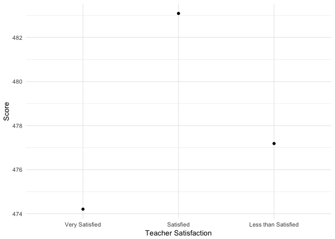

```r
joined1 %>% group_by(teacherSatisfaction) %>% summarise(Score = mean(mathSuccess)) %>% filter(!is.na(teacherSatisfaction)) %>%  ggplot(aes(x = as.factor(teacherSatisfaction), y = Score)) + geom_point() + labs(x="Teacher Satisfaction") + scale_x_discrete(breaks = 1:3, labels = c("Very Satisfied", "Satisfied", "Less than Satisfied")) + theme_minimal()
```

```r
joined1 %>% group_by(teacherSatisfaction) %>% summarise(Score = mean(mathSuccess)) %>% filter(!is.na(teacherSatisfaction)) %>% hchart("point",hcaes(x = as.factor(teacherSatisfaction), y = Score)) %>%
  hc_add_theme(hc_theme_ffx()) %>%
  hc_xAxis(categories = c("Very Satisfied", "Satisfied", "Less than Satisfied"), title = list(text = "Job Satisfaction")) %>%
  hc_legend(enabled = TRUE)
```

[interactive chart not shown]

با توجه به کم بودن مقدار pvalue و همینطور توجه به تست می توان دید که میزان موفقیت دانش آموزان مستقل از رضایت شغلی معلمان نیست.

۲. والدینی که تحصیلات بیشتری دارند دارای فرزندان موفق تری می باشند.  
با کمک تست anova مشخص می کنیم که عامل تحصیلات والدین بر موفقیت دانش آموزان تاثیر گذار است. سپس با گرفتن T Test نشان می دهیم اینکه تحصیلات بیشتر باعث موفقیت کمتر دانش آموزان می شود غلط است. سپس این نتیجه را با نمودار نشان می دهیم.

```r
bsg %>% filter(bsdgedup<6) %>% select(idcntry, idbook, idschool, idclass, idstud , parentEducation = bsdgedup) -> parentEdu #lower is better
full_join(parentEdu, studentSuccess) %>% group_by(idcntry, idbook, idschool, idclass, idstud) %>% slice(1) ->joined2
for(i in 1:4){
  joined2 %>% filter(parentEducation==i | parentEducation==i+1) %>% t.test(mathSuccess ~ parentEducation, data = ., alt = "greater") %>% print()
}
```

```
##
##  Welch Two Sample t-test
##
## data:  mathSuccess by parentEducation
## t = 61.563, df = 92486, p-value < 2.2e-16
## alternative hypothesis: true difference in means is greater than 0
## 95 percent confidence interval:
##  35.57732      Inf
## sample estimates:
## mean in group 1 mean in group 2
##        519.2326        482.6786
##
##
##  Welch Two Sample t-test
##
## data:  mathSuccess by parentEducation
## t = 26.316, df = 93752, p-value < 2.2e-16
## alternative hypothesis: true difference in means is greater than 0
## 95 percent confidence interval:
##  16.4848     Inf
## sample estimates:
## mean in group 2 mean in group 3
##        482.6786        465.0947
##
##
##  Welch Two Sample t-test
##
## data:  mathSuccess by parentEducation
## t = 61.939, df = 50055, p-value < 2.2e-16
## alternative hypothesis: true difference in means is greater than 0
## 95 percent confidence interval:
##  47.08936      Inf
## sample estimates:
## mean in group 3 mean in group 4
##        465.0947        416.7207
##
##
##  Welch Two Sample t-test
##
## data:  mathSuccess by parentEducation
## t = 15.441, df = 31906, p-value < 2.2e-16
## alternative hypothesis: true difference in means is greater than 0
## 95 percent confidence interval:
##  13.4697     Inf
## sample estimates:
## mean in group 4 mean in group 5
##        416.7207        401.6449
```

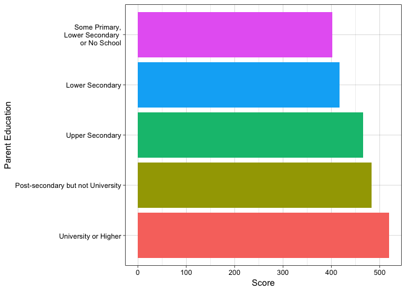

```r
joined2 %>% group_by(parentEducation) %>% summarise(Score = mean(mathSuccess)) %>% filter(!is.na(parentEducation)) %>% ggplot(aes(x = as.factor(parentEducation), y = Score, fill = as.factor(parentEducation))) + geom_col() +coord_flip() + labs(x="Parent Education") + scale_x_discrete(breaks = 1:5, labels = c("University or Higher", "Post-secondary but not University", "Upper Secondary", "Lower Secondary", "Some Primary,\n Lower Secondary \nor No School")) + theme_linedraw() + guides(fill=FALSE)
```

```r
joined2 %>% group_by(parentEducation) %>% summarise(Score = mean(mathSuccess)) %>% filter(!is.na(parentEducation)) %>% hchart("column",hcaes(x = as.factor(parentEducation), y = Score), name = "Parent Education") %>%
  hc_add_theme(hc_theme_sandsignika()) %>%
  hc_xAxis(categories = c("University or Higher", "Post-secondary but not University", "Upper Secondary", "Lower Secondary", "Some Primary, Lower Secondary or No School"), title = list(text = "Parent Education")) %>%
  hc_legend(enabled = TRUE)
```

[interactive chart not shown]

۳. امکانات رفاهی در خانه موجب پیشرفت تحصیلی می گردد.  
امکانات رفاهی به صورت عددی پیوسته اندازه گیری شده است که با کمک کوریلیشن تست ارتباط خطی بین موفقیت و امکانات رفاهی را می یابیم. این ارتباط در نمودار این پارامتر ها نیز واضح است.

```r
bsg %>% filter(bsbgher != 999999) %>% select(idcntry, idbook, idschool, idclass, idstud , homeResource = bsbgher) -> homeResource #higher is better
full_join(homeResource, studentSuccess) %>% group_by(idcntry, idbook, idschool, idclass, idstud) %>% slice(1) -> joined3
cor.test(joined3$mathSuccess, joined3$homeResource, alternative = "two.sided", method = "pearson")
```

```
##
##  Pearson's product-moment correlation
##
## data:  joined3$mathSuccess and joined3$homeResource
## t = 266.59, df = 274770, p-value < 2.2e-16
## alternative hypothesis: true correlation is not equal to 0
## 95 percent confidence interval:
##  0.4503447 0.4562860
## sample estimates:
##       cor
## 0.4533204
```

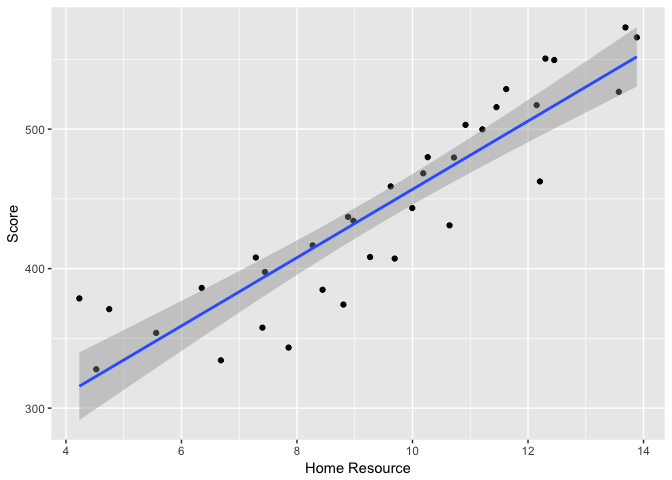

```r
joined3 %>% group_by(homeResource) %>% summarise(Score = mean(mathSuccess)) %>% filter(!is.na(homeResource)) %>%  ggplot(aes(x = homeResource, y = Score)) + geom_point() + geom_smooth(method='lm') + labs(x="Home Resource")
```

```r
joined3 %>% group_by(homeResource) %>% summarise(Score = mean(mathSuccess)) %>% filter(!is.na(homeResource))  %>%  hchart("point",hcaes(x = homeResource, y = Score)) %>%
  hc_add_theme(hc_theme_db()) %>%
  hc_xAxis(title = list(text = "Home Resources"))
```

[interactive chart not shown]

***

۴. محیط آرام مدرسه نقش مهمی در پیشرفت تحصیلی دارد.  
correlation test نشان می دهد که محیط آرام مدرسه نقش مهمی در پیشرفت تحصیلی دارد. نمودار نیز تا حدی گویای این مسئله و شیب مثبت پیشرفت با بهبود اوضاع مدرسه است.

```r
bsg %>% filter(bsbgsb!=999999) %>% select(idcntry, idbook, idschool, idclass, idstud ,schoolEnv = bsbgsb) -> schoolEnv #higher is better
full_join(schoolEnv, studentSuccess) %>% group_by(idcntry, idbook, idschool, idclass, idstud) %>% slice(1) -> joined4
cor.test(joined4$mathSuccess, joined4$schoolEnv, alternative = "two.sided", method = "pearson")
```

```
##
##  Pearson's product-moment correlation
##
## data:  joined4$mathSuccess and joined4$schoolEnv
## t = 95.693, df = 269980, p-value < 2.2e-16
## alternative hypothesis: true correlation is not equal to 0
## 95 percent confidence interval:
##  0.1774693 0.1847659
## sample estimates:
##       cor
## 0.1811201
```

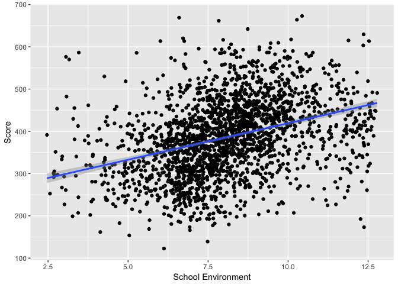

```r
joined4 %>% group_by(schoolEnv) %>% summarise(Score = mean(mathSuccess)) %>% filter(!is.na(schoolEnv)) %>%  ggplot(aes(x = schoolEnv, y = Score)) + geom_point() + geom_smooth(method='lm') + labs(x="School Environment")
```

```r
joined4 %>% group_by(schoolEnv) %>% summarise(Score = mean(mathSuccess)) %>% filter(!is.na(schoolEnv))  %>%  hchart("point",hcaes(x = schoolEnv, y = Score)) %>%
  hc_add_theme(hc_theme_db()) %>%
  hc_xAxis(title = list(text = "School Environment")) %>%
  hc_plotOptions(series = list(marker = list(radius = 2)))
```

[interactive chart not shown]

***

```r
btg %>% filter(btbg01!=99 & btbg04 < 8) %>% select(idcntry, idschool, idtealin, teacherExperience = btbg01, teacherAcademic = btbg04) -> teacherExpAca #higher is better in exp and lower is better in academic
full_join(teacherExpAca, studentSuccess) %>% group_by(idcntry, idbook, idschool, idclass, idstud) -> joined5
# testing teacherAcademic first with anova and then with t.test for more details
summary(aov(mathSuccess ~ as.factor(teacherExperience), data = joined5))
```

```
##                                  Df    Sum Sq Mean Sq F value Pr(>F)
## as.factor(teacherExperience)     54 1.721e+07  318790    28.4 <2e-16 ***
## Residuals                    249299 2.798e+09   11225
## ---
## Signif. codes:  0 '***' 0.001 '**' 0.01 '*' 0.05 '.' 0.1 ' ' 1
## 445581 observations deleted due to missingness
```

```r
for(i in 1:6){
  joined5 %>% filter(teacherAcademic==i | teacherAcademic==i+1) %>% t.test(mathSuccess ~ teacherAcademic, data = ., alt = "less") %>% print()
}
```

```
##
##  Welch Two Sample t-test
##
## data:  mathSuccess by teacherAcademic
## t = 6.2021, df = 509.46, p-value = 1
## alternative hypothesis: true difference in means is less than 0
## 95 percent confidence interval:
##      -Inf 30.30569
## sample estimates:
## mean in group 1 mean in group 2
##        419.0504        395.1065
##
##
##  Welch Two Sample t-test
##
## data:  mathSuccess by teacherAcademic
## t = -11.969, df = 4843.3, p-value < 2.2e-16
## alternative hypothesis: true difference in means is less than 0
## 95 percent confidence interval:
##       -Inf -21.39241
## sample estimates:
## mean in group 2 mean in group 3
##        395.1065        419.9080
##
##
##  Welch Two Sample t-test
##
## data:  mathSuccess by teacherAcademic
## t = -0.24479, df = 4377.3, p-value = 0.4033
## alternative hypothesis: true difference in means is less than 0
## 95 percent confidence interval:
##      -Inf 2.813118
## sample estimates:
## mean in group 3 mean in group 4
##        419.9080        420.3998
##
##
##  Welch Two Sample t-test
##
## data:  mathSuccess by teacherAcademic
```

[output cut: 16 more lines]

```
## sample estimates:
## mean in group 5 mean in group 6
##        482.8119        511.7468
##
##
##  Welch Two Sample t-test
##
## data:  mathSuccess by teacherAcademic
## t = -3.9234, df = 1802.1, p-value = 4.53e-05
## alternative hypothesis: true difference in means is less than 0
## 95 percent confidence interval:
##       -Inf -5.441581
## sample estimates:
## mean in group 6 mean in group 7
##        511.7468        521.1201
```

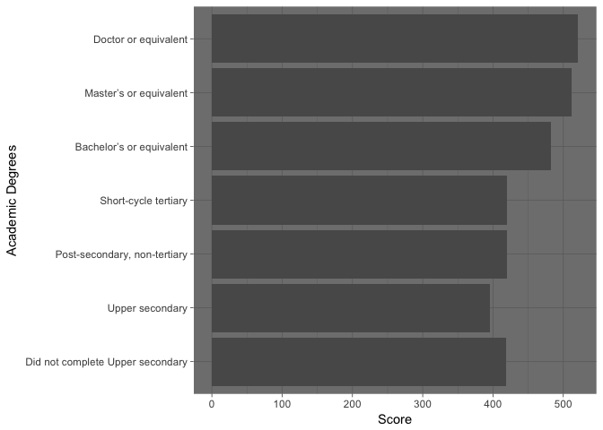

```r
joined5 %>% group_by(teacherAcademic) %>% summarise(Score = mean(mathSuccess)) %>% filter(!is.na(teacherAcademic)) %>%  ggplot(aes(x = as.factor(teacherAcademic), y = Score)) + geom_col() + labs(x="Academic Degrees") + scale_x_discrete(breaks = 1:7, labels = c("Did not complete Upper secondary", "Upper secondary", "Post-secondary, non-tertiary", "Short-cycle tertiary", "Bachelor’s or equivalent", "Master’s or equivalent", "Doctor or equivalent")) + theme_dark() + coord_flip()
```

```r
joined5 %>% group_by(teacherAcademic) %>% summarise(Score = mean(mathSuccess)) %>% filter(!is.na(teacherAcademic)) %>% hchart("bar",hcaes(x = as.factor(teacherAcademic), y = Score)) %>%
  hc_add_theme(hc_theme_monokai()) %>%
  hc_xAxis(categories = c("Did not complete Upper secondary", "Upper secondary", "Post-secondary, non-tertiary", "Short-cycle tertiary", "Bachelor’s or equivalent", "Master’s or equivalent", "Doctor or equivalent"), title = list(text = "Teacher Academic Background"))
```

[interactive chart not shown]

```r
# testing teacherExperience with correlation test
cor.test(joined5$mathSuccess, joined5$teacherExperience, alternative = "two.sided", method = "pearson")
```

```
##
##  Pearson's product-moment correlation
##
## data:  joined5$mathSuccess and joined5$teacherExperience
## t = 19.055, df = 249350, p-value < 2.2e-16
## alternative hypothesis: true correlation is not equal to 0
## 95 percent confidence interval:
##  0.03421127 0.04204987
## sample estimates:
##        cor
## 0.03813115
```

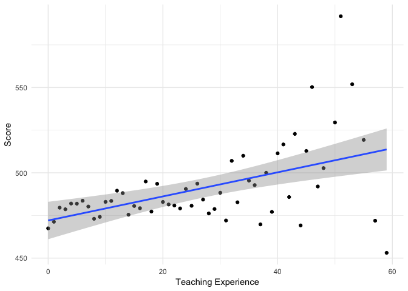

```r
joined5 %>% group_by(teacherExperience) %>% summarise(Score = mean(mathSuccess)) %>% filter(!is.na(teacherExperience)) %>%  ggplot(aes(x = teacherExperience, y = Score)) + geom_point() + labs(x="Teaching Experience") + geom_smooth(method = "lm") + theme_minimal()
```

```r
joined5 %>% group_by(teacherExperience) %>% summarise(Score = mean(mathSuccess)) %>% filter(!is.na(teacherExperience)) %>%  hchart("point",hcaes(x = teacherExperience, y = Score)) %>%
  hc_add_theme(hc_theme_google()) %>%
  hc_xAxis(title = list(text = "Teaching Experience"))
```

[interactive chart not shown]

۶. پسران در کاربرد هندسه قوی تر هستند.  
T Test این فرض را نمی تواند اثبات کند و با توجه به نزدیکی میانگین ها می توان گفت احتمالن پسر یا دختر بودن در موفقیت سوالات هندسه تاثیری ندارد!

```r
timss %>% filter(topic_area == "Geometric Shapes" & cognitive_domain == "Applying") %>% select(female = correct_ratio_per_question_female, male = correct_ratio_per_question_male) %>% tidyr::gather("female","male",key = "gender",value = "score") -> girlsvsboys
t.test(score ~ gender,data = girlsvsboys,alt = "greater")
```

```
##
##  Welch Two Sample t-test
##
## data:  score by gender
## t = -0.18973, df = 813.86, p-value = 0.5752
## alternative hypothesis: true difference in means is greater than 0
## 95 percent confidence interval:
##  -0.02832897         Inf
## sample estimates:
## mean in group female   mean in group male
##            0.4454567            0.4483834
```

```r
girlsvsboys %>% group_by(gender) %>% summarise(mean = mean(score) %>% round(3)) %>%
  hchart("column",hcaes(x = gender,y = mean), name = "score") %>%
  hc_add_theme(hc_theme_economist())
```

[interactive chart not shown]

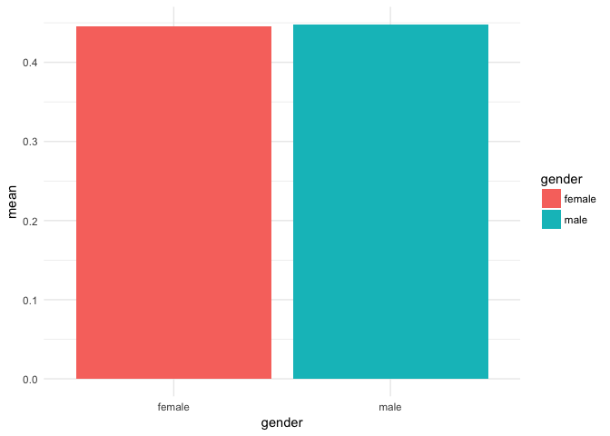

```r
girlsvsboys %>% group_by(gender) %>% summarise(mean = mean(score) %>% round(3)) %>% ggplot(aes(x = gender, y = mean, fill = gender)) + geom_col() + theme_minimal()
```

۷. تغذیه دانش آموزان نقش اساسی در یادگیری آنها دارد.

۸. مدارس با امکانات بیشتر دارای عملکرد بهتری می باشند.

۹. علت افت تحصیلی عدم مشارکت در کلاس است.

۱۰. دانش آموزان ایرانی در استدلال قوی تر از کاربرد هستند.  
T Test نشان می دهد این فرض رد می شود و می توان گفت دانش آموزان ایرانی در کاربرد قوی تر از استدلال عمل می کنند! نمودار نیز گویای این مسئله است.

```r
timss %>% filter(Country == "Iran, Islamic Rep. of" & cognitive_domain == "Reasoning") %>% select(question, reasoning = correct_ratio_per_question) -> reasoningTable
timss %>% filter(Country == "Iran, Islamic Rep. of" & cognitive_domain == "Applying") %>% select(question, applying = correct_ratio_per_question) -> applyingTable
full_join(reasoningTable, applyingTable) %>% select(reasoning, applying) %>% tidyr::gather("reasoning","applying",key = "type",value = "score") %>% filter(!is.na(score)) -> reasoningvsapplying
t.test(score ~ type, data = reasoningvsapplying, alt = "greater")
```

```
##
##  Welch Two Sample t-test
##
## data:  score by type
## t = 2.6374, df = 90.055, p-value = 0.00492
## alternative hypothesis: true difference in means is greater than 0
## 95 percent confidence interval:
##  0.02566765        Inf
## sample estimates:
##  mean in group applying mean in group reasoning
##               0.3233984               0.2540000
```

```r
reasoningvsapplying %>% group_by(type) %>% summarise(mean = mean(score) %>% round(3)) %>%
  hchart("column",hcaes(x = type,y = mean), name = "score") %>%
  hc_add_theme(hc_theme_darkunica())
```

[interactive chart not shown]

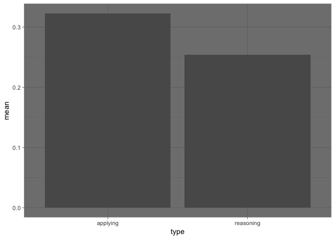

```r
reasoningvsapplying %>% group_by(type) %>% summarise(mean = mean(score) %>% round(3)) %>% ggplot(aes(x = type, y = mean)) + geom_col() + theme_dark()
```

سه گزاره جالب کشف کنید و ادعای خود را ثابت نمایید.

```r
bsg %>% filter(bsdgslp < 4) %>% select(idcntry, idbook, idschool, idclass, idstud , likePhysics = bsdgslp) -> likePhysics
full_join(likePhysics, studentSuccess) %>% group_by(idcntry, idbook, idschool, idclass, idstud) %>% slice(1) -> joinedp1
for(i in 1:2){
  joined2 %>% filter(parentEducation==i | parentEducation==i+1) %>% t.test(mathSuccess ~ parentEducation, data = ., alt = "greater") %>% print()
}
```

```
##
##  Welch Two Sample t-test
##
## data:  mathSuccess by parentEducation
## t = 61.563, df = 92486, p-value < 2.2e-16
## alternative hypothesis: true difference in means is greater than 0
## 95 percent confidence interval:
##  35.57732      Inf
## sample estimates:
## mean in group 1 mean in group 2
##        519.2326        482.6786
##
##
##  Welch Two Sample t-test
##
## data:  mathSuccess by parentEducation
## t = 26.316, df = 93752, p-value < 2.2e-16
## alternative hypothesis: true difference in means is greater than 0
## 95 percent confidence interval:
##  16.4848     Inf
## sample estimates:
## mean in group 2 mean in group 3
##        482.6786        465.0947
```

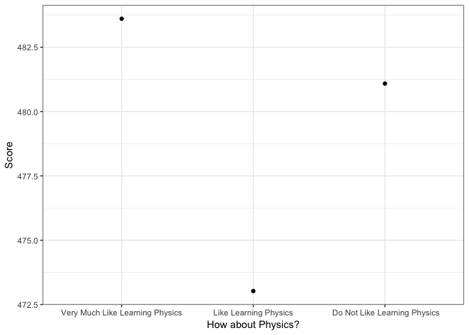

```r
  joinedp1 %>% group_by(likePhysics) %>% summarise(Score = mean(mathSuccess)) %>% filter(!is.na(likePhysics)) %>% ggplot(aes(x = as.factor(likePhysics), y = Score, fill = as.factor(likePhysics))) + geom_point() + labs(x="How about Physics?") + scale_x_discrete(breaks = 1:3, labels = c("Very Much Like Learning Physics", "Like Learning Physics", " Do Not Like Learning Physics")) + theme_bw() + guides(fill=FALSE)
```

```r
joinedp1 %>% group_by(likePhysics) %>% summarise(Score = mean(mathSuccess)) %>% filter(!is.na(likePhysics)) %>% hchart("point",hcaes(x = as.factor(likePhysics), y = Score), name = "How about physics?") %>%
  hc_add_theme(hc_theme_tufte2()) %>%
  hc_xAxis(categories =  c("Very Much Like Learning Physics", "Like Learning Physics", " Do Not Like Learning Physics")) %>%
  hc_legend(enabled = TRUE)
```

[interactive chart not shown]

```r
bcg %>% filter(bcbg08a <3) %>% select(idcntry, idschool, place = bcbg08a) -> place
full_join(studentSuccess, place) %>% group_by(idcntry, idschool) -> joinedp2
t.test(mathSuccess ~ place,data = joinedp2,alt = "greater")
```

```
##
##  Welch Two Sample t-test
##
## data:  mathSuccess by place
## t = 200.15, df = 598150, p-value < 2.2e-16
## alternative hypothesis: true difference in means is greater than 0
## 95 percent confidence interval:
##  50.33145      Inf
## sample estimates:
## mean in group 1 mean in group 2
##        503.3790        452.6305
```

```r
joinedp2 %>% group_by(place) %>% summarise(mean = mean(mathSuccess, na.rm = TRUE) %>% round(3)) %>%
  hchart("column",hcaes(x = place,y = mean)) %>%
  hc_add_theme(hc_theme_elementary()) %>%
  hc_xAxis(categories = c("","Have", "Doesn't Have"), title = list(text = "Have place for doing homework"))
```

[interactive chart not shown]

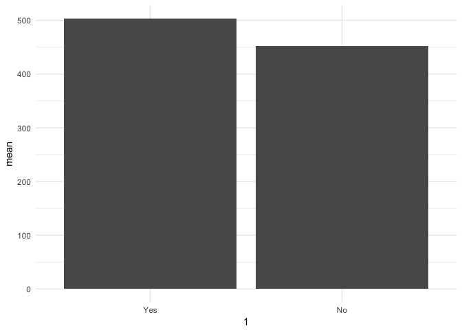

```r
joinedp2 %>% group_by(place) %>% summarise(mean = mean(mathSuccess, na.rm = TRUE)) %>% filter(!is.na(place)) %>% ggplot(aes(x = as.factor(place), y = mean)) + geom_col() + theme_minimal() + scale_x_discrete(1:2,labels = c("Yes", "No")) + labs(x = "Having place for doing homeworks")
```

معلم های زن مربی های بهتری برای ریاضی هستند!  
T Test نشان می دهد معلم های زن دانش آموزان موفق تری در ریاضی دارند.

```r
btg %>% filter(btbg02 < 3) %>%  select(idcntry, idschool, idtealin, sex = btbg02) -> teacherSex #lower is better
full_join(teacherSex, studentSuccess) -> joinedp3
t.test(mathSuccess ~ sex,data = joinedp3,alt = "great")
```

```
##
##  Welch Two Sample t-test
##
## data:  mathSuccess by sex
## t = 54.15, df = 233920, p-value < 2.2e-16
## alternative hypothesis: true difference in means is greater than 0
## 95 percent confidence interval:
##  22.00314      Inf
## sample estimates:
## mean in group 1 mean in group 2
##        488.1845        465.4920
```

```r
joinedp3 %>% group_by(sex) %>% summarise(mean = mean(mathSuccess, na.rm = TRUE)) %>% filter(!is.na(sex)) %>%
  hchart("column",hcaes(x = sex,y = mean)) %>%
  hc_add_theme(hc_theme_sandsignika()) %>%
  hc_xAxis(categories = c("", "Female", "Male"), title = list(text = "Sex of Teachers"))
```

[interactive chart not shown]

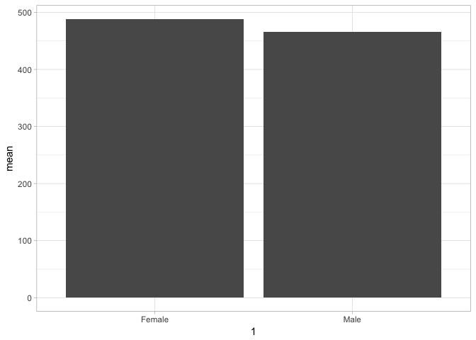

```r
joinedp3 %>% group_by(sex) %>% summarise(mean = mean(mathSuccess, na.rm = TRUE)) %>% filter(!is.na(sex)) %>% ggplot(aes(x = as.factor(sex), y = mean)) + geom_col() + theme_light() + scale_x_discrete(1:2,labels = c("Female", "Male"))
```